# AI_Internship_Local

### AI Internship challenge -- 2021

**Azercosmos**

Let us first start by importing used libraries. (In case not installed, run below cell to install libraries)

```python
!pip install numpy pandas geopandas matplotlib rasterio sklearn
```

```python
# importing necessary libraries
import numpy as np
import pandas as pd
import geopandas as gpd
import matplotlib.pyplot as plt
import rasterio.mask
from rasterio.plot import  show
from sklearn import cluster
from sklearn.metrics import classification_report
```

First, start by reading and plotting the shape file:

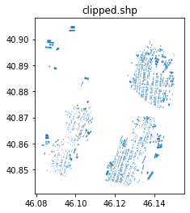

```python
# path to the shape file
shp_file = "clipped.shp"
shape = gpd.read_file(shp_file)
shape.plot()
plt.title(shp_file)
plt.show()
```

```python
# to analyze the structure of shape file
shape.head()
```

|  | fid | Rayon | Sahe | Qeyd | X | Y | Qeyri_yash | Heyet | ƏVD | Sahe_ha | geometry |
| --- | --- | --- | --- | --- | --- | --- | --- | --- | --- | --- | --- |
| 0 | 18.0 | Şəmkir | 457.561525 | None | 46.132647 | 40.860052 | None | Heyet | 14 | 0.045756 | POLYGON ((46.13246 40.86016, 46.13289 40.86004... |
| 1 | 19.0 | Şəmkir | 404.099991 | None | 46.132600 | 40.859935 | None | Heyet | 14 | 0.040410 | POLYGON ((46.13242 40.86004, 46.13283 40.85992... |
| 2 | 20.0 | Şəmkir | 797.963543 | None | 46.131807 | 40.859884 | None | Heyet | 14 | 0.079796 | POLYGON ((46.13169 40.86004, 46.13201 40.85997... |
| 3 | 21.0 | Şəmkir | 442.155291 | None | 46.131568 | 40.859946 | None | Heyet | 14 | 0.044216 | POLYGON ((46.13156 40.86012, 46.13169 40.86009... |
| 4 | 22.0 | Şəmkir | 126.150396 | None | 46.131382 | 40.859765 | None | Heyet | 14 | 0.012615 | POLYGON ((46.13127 40.85982, 46.13152 40.85976... |

To find *the regions of the interest*, I will do clustering using the module `sklearn.cluster`. K-Means clustering will be used with the `num_of_clusters` parameter which I set to 3.

```python
# number of clusters
num_of_clusters = 3
kmeans = cluster.KMeans(n_clusters=num_of_clusters)
print(kmeans)
```

```
KMeans(n_clusters=3)
```

To fit the model, I should preprocess the data such that `coordinates` matrix will contain x and y coordinates. Moreover `NaN` values will be dropped.

```python
# coordinates matrix
coordinates = shape[['X','Y']]
#dropping nan values
coordinates = coordinates.dropna()
print(coordinates)
```

```
              X          Y
0     46.132647  40.860052
1     46.132600  40.859935
2     46.131807  40.859884
3     46.131568  40.859946
4     46.131382  40.859765
...         ...        ...
2860  46.131062  40.851093
2861  46.142597  40.873252
2862  46.136290  40.884190
2863  46.104257  40.863014
2864  46.134412  40.851407

[2865 rows x 2 columns]
```

Now, let us fit the model with coordinates and visualize the output :

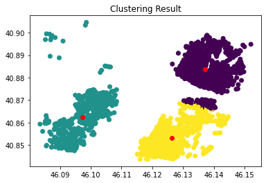

```python
# fit the model
model = kmeans.fit(coordinates)
# predict the result
clusters = model.predict(coordinates)
# scatter plot predicted result
plt.scatter(coordinates['X'],coordinates['Y'],c=clusters)
# red dots represent cluster centers
center_of_clusters = model.cluster_centers_
plt.scatter(center_of_clusters[:,0],center_of_clusters[:,1],c='red')
plt.title("Clustering Result")
```

Now select the polygons corresponding to the clusters (0,1,2) to crop the shape file acccordingly :

```python
# dictionary holding polygons for corresponding cluster
cluster_polygons={}
for i in range(num_of_clusters):
    cluster_polygons[i]=[]
for i in zip(clusters,shape['geometry']):
    cluster_polygons[i[0]].append(i[1])
```

Just before doing cropping, let us open and visualize the raster file :

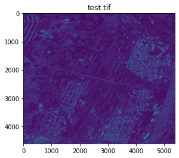

```python
# path to raster file
raster_file = "test.tif"
raster = rasterio.open(raster_file)
plt.title(raster_file)
show(raster.read(3))
```

Finally, let us crop the respective region of the interest and corresponding raster file part for each cluster.

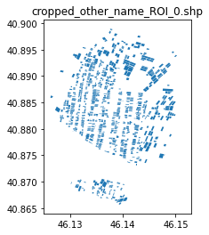

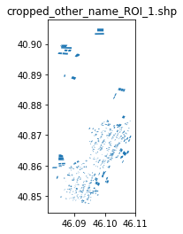

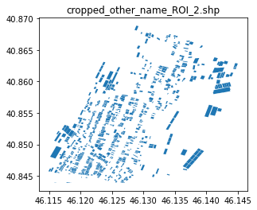

```python
for i in cluster_polygons.keys():
    # output file name as mentioned in the pdf
    out_file_name = "cropped_other_name_ROI_"+str(i)+".shp"
    out_file = gpd.GeoDataFrame(geometry=cluster_polygons[i])
    # plot of the cropped part
    out_file.plot()
    plt.title(out_file_name)
    # write output file
    out_file.to_file(out_file_name)
    # cropping corresponding part of raster file
    out_image,out_transform = rasterio.mask.mask(raster,cluster_polygons[i],crop=True)
    out_meta = raster.meta
    out_meta.update({
        "height":out_image.shape[1],
        "width":out_image.shape[2],
        "transform":out_transform})
    # output raster file name as mentioned in the pdf
    out_raster_name = "cropped_other_name_ROI_"+str(i)+".tif"
    # writing the cropped raster file part
    with rasterio.open(out_raster_name,"w",**out_meta) as raster_out:
        raster_out.write(out_image)
```

Finally, we can see visualize the cropped raster files as well.

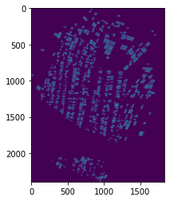

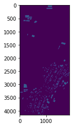

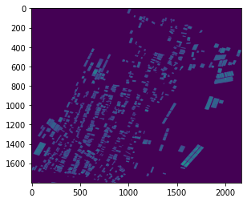

```python
raster.close()
for i in range(3):
    filename = "cropped_other_name_ROI_"+str(i)+".tif"
    raster = rasterio.open(filename)
    show(raster.read(3))
    raster.close()
```

> Best regards. written by *Vahab Jabrayilov*